# Teenage Alcoholism (Multilevel Linear Model)

Shusei Yokoi

Curran, Stice, and Chassin (Journal of Consulting and Clinical Psychology, 1997) collected data on 82 adolescents at three time points starting at age 14 to assess factors that affect teen drinking behavior. Key variables in the data set are:

- id = numerical identifier for subject
- age = 14, 15, or 16
- coa = 1 if the teen is a child of an alcoholic parent; 0 otherwise
- male = 1 if male; 0 if female
- peer = a measure of peer alcohol use, taken when each subject was 14. This is the square root of the sum of two 6-point items about the proportion of friends who drink occasionally or regularly.
- alcuse = the primary response. Four items—(a) drank beer or wine, (b) drank hard liquor, (c) 5 or more drinks in a row, and (d) got drunk—were each scored on an 8-point scale, from 0=“not at all” to 7=“every day.” Then alcuse is the square root of the sum of these four items.

```r
library(ggplot2)
library(lme4)
library(nlme)
library(tidyverse)
library(effects)
library(readr)
```

Primary research questions included:  
do trajectories of alcohol use differ by parental alcoholism?  
do trajectories of alcohol use differ by peer alcohol use?

Level One and Level Two predictors.  
Level One: A single observation at the occasion  
Level Two: Individual Student

**spaghetti plot** showing alcohol use over time for all 82 subjects.

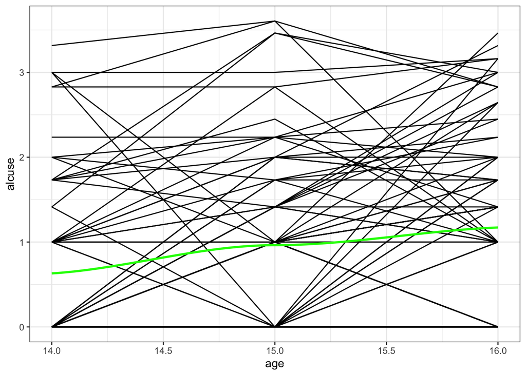

```r
alcohol = read.delim("https://www.rossmanchance.com/stat414/data/alcohol.txt", "\t", header=TRUE)

ggplot(data = alcohol, aes(y = alcuse, x = age, group=id)) +
     geom_line() +
     geom_smooth(aes(group=1),color="green",size=1, se=F, method="loess") +
     theme_bw()
```

There is some variability among the different time period. Meaning the trend is non-linear. However the smooth line/the mean of the data may have a linear relationship.

Graph by whether or not the teen had alcoholic parents.

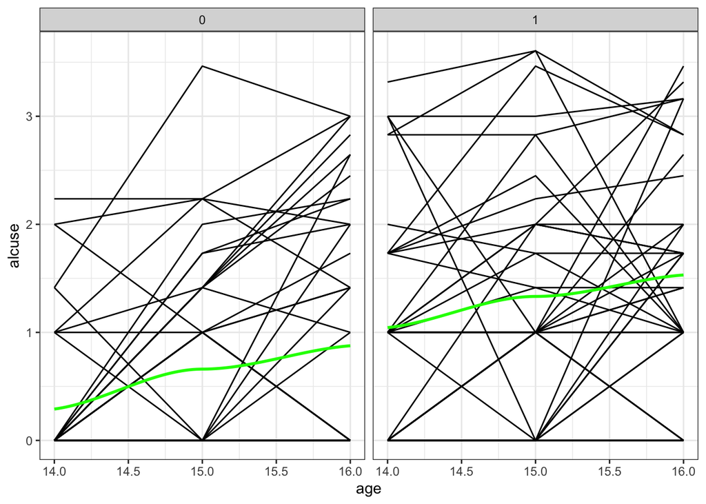

```r
ggplot(data = alcohol, aes(y = alcuse, x = age, group=id)) +
  geom_line() +
  facet_wrap(.~coa) +
  geom_smooth(aes(group=1),color="green",size=1, se=F, method="loess") +
  theme_bw()
```

The trend is still non-linear. Between the two grap, the average aluse is slightly higher for the teen with alcholic parents.

```r
model0 = lme(alcuse ~ age, random = ~1|id, data = alcohol )
summary(model0)
```

```
## Linear mixed-effects model fit by REML
##  Data: alcohol
##        AIC      BIC    logLik
##   662.0657 676.0544 -327.0329
##
## Random effects:
##  Formula: ~1 | id
##         (Intercept)  Residual
## StdDev:   0.7723689 0.7010646
##
## Fixed effects: alcuse ~ age
##                  Value Std.Error  DF   t-value p-value
## (Intercept) -3.1378163 0.8267862 163 -3.795197   2e-04
## age          0.2706514 0.0547439 163  4.943951   0e+00
##  Correlation:
##     (Intr)
## age -0.993
##
## Standardized Within-Group Residuals:
##         Min          Q1         Med          Q3         Max
## -2.19816373 -0.66940130  0.03000748  0.44727545  2.66167170
##
## Number of Observations: 246
## Number of Groups: 82
```

Total variance = 0.7723689^2 + 0.7010646^2 = 1.0880453  
ICC = 0.7723689^2 /1.0880453 = 0.5482802

Run an unconditional growth model with age as the time variable at Level One.

```r
model1 = lme(alcuse ~ age, random = ~ age| id, data = alcohol)
summary(model1)
```

```
## Linear mixed-effects model fit by REML
##  Data: alcohol
##        AIC      BIC    logLik
##   655.1916 676.1746 -321.5958
##
## Random effects:
##  Formula: ~age | id
##  Structure: General positive-definite, Log-Cholesky parametrization
##             StdDev    Corr
## (Intercept) 5.7483519 (Intr)
## age         0.3938930 -0.991
## Residual    0.5807685
##
## Fixed effects: alcuse ~ age
##                  Value Std.Error  DF   t-value p-value
## (Intercept) -3.1378163 0.9311764 163 -3.369733   9e-04
## age          0.2706514 0.0628391 163  4.307054   0e+00
##  Correlation:
##     (Intr)
## age -0.995
##
## Standardized Within-Group Residuals:
##         Min          Q1         Med          Q3         Max
## -2.48286956 -0.37932768 -0.07858233  0.38875633  2.49283620
##
## Number of Observations: 246
## Number of Groups: 82
```

The average alcuse for the average students at age 0 is -3.1378163

**Centering**  
(Create age14 = age-14)

```r
alcohol = alcohol %>%
  mutate(age14 = age -14)
```

```r
model1 = lmer(alcuse ~ age14 +(age14 | id), data = alcohol)
summary(model1)
```

```
## Linear mixed model fit by REML ['lmerMod']
## Formula: alcuse ~ age14 + (age14 | id)
##    Data: alcohol
##
## REML criterion at convergence: 643.2
##
## Scaled residuals:
##      Min       1Q   Median       3Q      Max
## -2.48287 -0.37933 -0.07858  0.38876  2.49284
##
## Random effects:
##  Groups   Name        Variance Std.Dev. Corr
##  id       (Intercept) 0.6355   0.7972
##           age14       0.1552   0.3939   -0.23
##  Residual             0.3373   0.5808
## Number of obs: 246, groups:  id, 82
##
## Fixed effects:
##             Estimate Std. Error t value
## (Intercept)  0.65130    0.10573   6.160
## age14        0.27065    0.06284   4.307
##
## Correlation of Fixed Effects:
##       (Intr)
## age14 -0.441
```

Plot model1 vs. (the original) peer alcohol use variable.

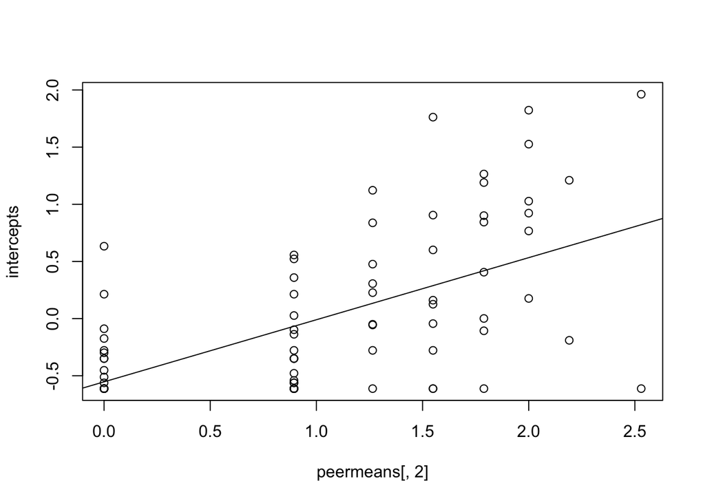

```r
peermeans = aggregate(alcohol[, 6], by=list(alcohol$id), mean)
intercepts = ranef(model1)$id[,1]
plot(intercepts ~ peermeans[,2])
abline(lm(intercepts ~ peermeans[,2]))
```

As the peer alchol use increase, there is higher probability that the observation is already using the alcohol as the age of 14.

```r
model_5 = lmer(alcuse ~ age14 + coa + peer + (age14 | id), data = alcohol)
summary(model_5)
```

```
## Linear mixed model fit by REML ['lmerMod']
## Formula: alcuse ~ age14 + coa + peer + (age14 | id)
##    Data: alcohol
##
## REML criterion at convergence: 603.7
##
## Scaled residuals:
##     Min      1Q  Median      3Q     Max
## -2.6000 -0.3985 -0.1048  0.3733  2.3605
##
## Random effects:
##  Groups   Name        Variance Std.Dev. Corr
##  id       (Intercept) 0.2621   0.5120
##           age14       0.1552   0.3939   -0.08
##  Residual             0.3373   0.5808
## Number of obs: 246, groups:  id, 82
##
## Fixed effects:
##             Estimate Std. Error t value
## (Intercept) -0.22635    0.14036  -1.613
## age14        0.27065    0.06284   4.307
## coa          0.57120    0.14898   3.834
## peer         0.60922    0.10226   5.958
##
## Correlation of Fixed Effects:
##       (Intr) age14  coa
## age14 -0.254
## coa   -0.359  0.000
## peer  -0.664  0.000 -0.162
```